# act_report

## Report: act_report

This report describes the analysis, visualizations and insight gathered from the wrangled data.

I investigated some questions to get insights which are:

1. Which source were tweets made from the most?
2. Which dog stage had the highest dog rating?
3. Which dog stage had the highest retweet count?
4. Which dog stage had the highest favorite count?

For the first question, I used the pandas value counts function to get the count for each tweet source from the master datframe. After that, a bar chart was depicted to show the most source for tweets. It was discovered that most sources came from twitter for iphone with a total of 1932.

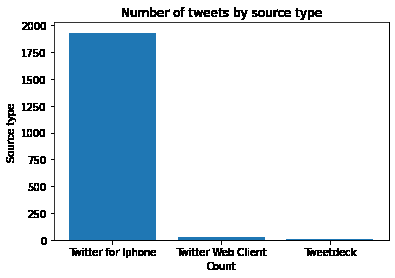

For the second question, before analysing, I discovered that there was an outlier dog rating of 177.6 in row 722 of the dataframe. This row was dropped so as to avoid bias in the analysis. Pandas groupby function was then used to group each dog stage by the highest rating. A pie chart was then depicted to show the various maximum ratings by percentage for each dog stage. It was discovered that the pupper dog stage received the maximum rating with 25.7%.

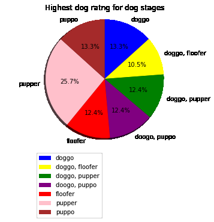

For the third question, I used the pandas groupy function to get the dog stages and the sum of their retweeet counts. I plotted the results on a bar chart using seaborn. It was discovered that the pupper dog stage had the highest number of retweet count of 478,883.

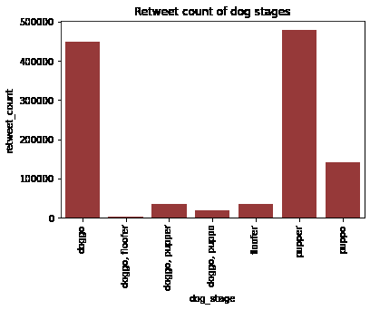

For the fourth question, I used the pandas groupy function to get the dog stages and the sum of their favorite counts. I plotted the results on a bar chart using seaborn. It was discovered that the pupper dog stage had the highest number of favorite count of 1,457,356.

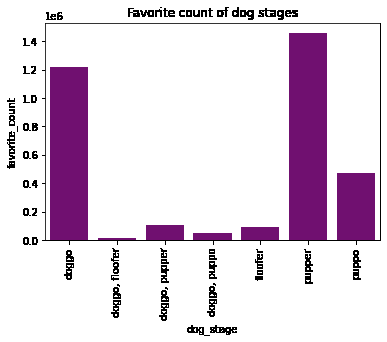